# Impact of Storms in the United States

### Synopsis

The purpose of this anaylsis is to determine which types of storms and weather events are most harmful with respect to population health and which have the greatest economic consequences. Analyzing storm data from the National Oceanic and Atmospheric Administration can help answer these questions. This document details step-by-step analysis so that the reader may reproduce it in its entirety.

### Analytical Approach

To answer the question, “Which events are most harmful to population health?”, the analysis below simply sums up the fatalities and injuries by type of event and sort in decreasing order of the number of fatalities and injuries.

Similarly, to answer the question, “Which events have the greatest economic consequences?”, the analysis below simply sums the crop damage and property damage by the type of event and sort in decreasing order of total damage value.

#### An Alternative Approach

From the perspective of the municipal manager seeking to allocate resources to minimize the impact of storms and emergencies, perhaps these data can be used to answer the question, “What is the priority list of events that we should be prepared for in the U.S. today?” Instead of summarizing which events have had the greatest impact, the analysis could propose a list of event types to prepare for based on both expected occurrences of that event type and expected impact for each occurrence in the next 12 months. The guiding philosophy behind this approach is that, event types that have the largest expected consequences should be prioritized over those that are expected to be less impactful.

### Data Processing

Set global parameters and identify the R packages that were used in this analysis

```r
library(knitr)
library(data.table)
library(ggplot2)
library(plyr)
library(scales)
opts_chunk$set(cache = FALSE, fig.align = 'center', echo = TRUE)
```

Download the data

```r
# data can be downloaded from this url
url <- c("https://d396qusza40orc.cloudfront.net/repdata%2Fdata%2FStormData.csv.bz2")

# set destination for downloaded file
destFile.path <- c("./data/stormdata.csv.bz2")

if (!file.exists(destFile.path)) {
    dir.create("./data/")
    download.file(url, destfile = "./data/stormdata.csv.bz2", method = "curl")
}
```

Load data into memory

```r
stormData <- read.table("./data/stormdata.csv.bz2", sep = ",", header = TRUE)
```

For faster and easier processing, drop unused columns and format data into a data table

```r
stormData <- stormData[,c("BGN_DATE", "EVTYPE", "FATALITIES", "INJURIES", "PROPDMG", "CROPDMG")]
stormData <- data.table(stormData)
```

Using the `BGN_DATE` variable, calculate the year of the event.

```r
stormData <- stormData[, date:= as.Date(stormData$BGN_DATE, "%m/%d/%Y %H:%M:%S")]
stormData <- stormData[, year:= year(date)]
```

Create a new column for cleaned versions of event categories and group similar events together. Focus on the events with meaningful injury, fatality, and damage values.

```r
stormData <- stormData[, EventCategory:= tolower(EVTYPE)]

indicies <- grep("avalance|avalanche", stormData$EventCategory)
stormData$EventCategory[indicies] <- c("avalanche")

indicies <- grep("blizzard", stormData$EventCategory)
stormData$EventCategory[indicies] <- c("blizzard")

indicies <- grep("coastal.*flood", stormData$EventCategory)
stormData$EventCategory[indicies] <- c("coastal flood")

indicies <- grep("dry.*microburst", stormData$EventCategory)
stormData$EventCategory[indicies] <- c("dry microburst")

indicies <- grep("extreme.*cold|wind.*chill", stormData$EventCategory)
stormData$EventCategory[indicies] <- c("wind chill")

indicies <- grep("flash.*flo{2,3}d|flood.*flash", stormData$EventCategory)
stormData$EventCategory[indicies] <- c("flash flood")

indicies <- grep("^flood", stormData$EventCategory)
stormData$EventCategory[indicies] <- c("flood")

indicies <- grep("^frost", stormData$EventCategory)
stormData$EventCategory[indicies] <- c("frost")

indicies <- grep("^funnel", stormData$EventCategory)
stormData$EventCategory[indicies] <- c("funnel cloud")

indicies <- grep("summary", stormData$EventCategory)
stormData$EventCategory[indicies] <- c("summary")

indicies <- grep("wa(y?)ter.*spout", stormData$EventCategory)
stormData$EventCategory[indicies] <- c("waterspout")

indicies <- grep("thunder|thuder|tstm|thuner|thunde|tunder", stormData$EventCategory)
stormData$EventCategory[indicies] <- c("thunderstorm")

indicies <- grep("^(rip current)", stormData$EventCategory)
stormData$EventCategory[indicies] <- c("rip current")

indicies <- grep("^tropical", stormData$EventCategory)
stormData$EventCategory[indicies] <- c("tropical storm")

indicies <- grep("^tornado|torndao", stormData$EventCategory)
stormData$EventCategory[indicies] <- c("tornado")

indicies <- grep("^high wind", stormData$EventCategory)
stormData$EventCategory[indicies] <- c("high wind")

indicies <- grep("^hurricane", stormData$EventCategory)
stormData$EventCategory[indicies] <- c("hurricane")

indicies <- grep("heavy.*snow", stormData$EventCategory)
stormData$EventCategory[indicies] <- c("heavy snow")

indicies <- grep("hail", stormData$EventCategory)
stormData$EventCategory[indicies] <- c("hail")

indicies <- grep("heavy.*rain|heavy.*shower", stormData$EventCategory)
stormData$EventCategory[indicies] <- c("heavy rain")

indicies <- grep("lig(n|h)t(n?)ing", stormData$EventCategory)
stormData$EventCategory[indicies] <- c("lightning")

indicies <- grep("strong.*wind", stormData$EventCategory)
stormData$EventCategory[indicies] <- c("strong wind")

indicies <- grep("wild.*fire|forest.*fire", stormData$EventCategory)
stormData$EventCategory[indicies] <- c("wild fire")

indicies <- grep("^wint(e?)r", stormData$EventCategory)
stormData$EventCategory[indicies] <- c("winter storm")

indicies <- grep("^volcanic", stormData$EventCategory)
stormData$EventCategory[indicies] <- c("volcanic ash")

indicies <- grep("(high|heavy) surf", stormData$EventCategory)
stormData$EventCategory[indicies] <- c("high surf")

indicies <- grep("((excessive|extreme) heat)|drought|heat wave|heat", stormData$EventCategory)
stormData$EventCategory[indicies] <- c("excessive heat")

indicies <- grep("urban|((sml|small) stream)", stormData$EventCategory)
stormData$EventCategory[indicies] <- c("urban flood")
```

To answer the two main questions, calculate the overall sums of each measure for each event category. While the data extend as far back as 1950, much more data is available in recent years (since 1995). As a result, the sums predominantly reflect the time period since then.

```r
stormDataByEventCategory <- stormData[,
    list(totalFatalities      = sum(FATALITIES, na.rm = TRUE),
         totalInjuries        = sum(INJURIES, na.rm = TRUE),
         totalCropDamage      = sum(CROPDMG, na.rm = TRUE),
         totalPropertyDamage  = sum(PROPDMG, na.rm = TRUE)),
    by = c("EventCategory")]

stormDataByEventCategory <- stormDataByEventCategory[, totalHumanHarm:= totalFatalities + totalInjuries]
stormDataByEventCategory <- stormDataByEventCategory[, totalEconomicDamage:= totalCropDamage + totalPropertyDamage]
```

To answer the forward-looking question from the perspective of the municipal manager, we need a bit more information:

1. Total overall number of fatalities for each event type *(included from above)*
2. Total overall number of injuries for each event type *(included from above)*
3. Total overall crop damage for each event type *(included from above)*
4. Total overall property damage for each event type *(included from above)*
5. Average number of annual event occurrences for each event type
6. Total number of occurrences for each event type
7. Average fatalities per event in event type
8. Average injuries per event in event type
9. Average crop damage per event in event type
10. Average property damager per event in event type
11. Estimated 12 month fatality for each event type *(annual avg # of events x avg fatalities per event)*
12. Estimated 12 month injury count for each event type *(annual avg # of events x avg injuries per event)*
13. Estimated 12 month crop damage for each event type *(annual avg # of events x avg crop damage per event)*
14. Estimated 12 month property damage for each event type *(annual avg # of events x avg property damage per event)*

Calculate and merge average and total event counts

```r
eventCountsByYear <- data.table(count(stormData, c("EventCategory", "year")))
totalCountsByEventCategory <- eventCountsByYear[, list(totalEventCount = sum(freq)),
                                                by = c("EventCategory")]

avgCountsByEventCategory <- eventCountsByYear[, list(avgAnnualEventCount = mean(freq)),
                                              by = c("EventCategory")]

# merge
stormDataByEventCategory <- merge(x = stormDataByEventCategory,
                                  y = avgCountsByEventCategory,
                                  by = c("EventCategory"),
                                  all = FALSE)

stormDataByEventCategory <- merge(x = stormDataByEventCategory,
                                  y = totalCountsByEventCategory,
                                  by = c("EventCategory"),
                                  all = FALSE)
```

Calculate average measure per event in each event category

```r
stormDataByEventCategory <- stormDataByEventCategory[,avgFatalitiesPerEvent:= totalFatalities / totalEventCount]
stormDataByEventCategory <- stormDataByEventCategory[,avgInjuriesPerEvent:= totalInjuries / totalEventCount]
stormDataByEventCategory <- stormDataByEventCategory[,avgCropDamagePerEvent:= totalCropDamage / totalEventCount]
stormDataByEventCategory <- stormDataByEventCategory[,avgPropertyDamagePerEvent:= totalPropertyDamage / totalEventCount]
```

Calculate estimates of each measure for the next 12 months Estimated NTM Measure = Avg Measure Per Event (x) Avg Annual Event Count

```r
stormDataByEventCategory <- stormDataByEventCategory[,NTMEstFatalities:= avgFatalitiesPerEvent * avgAnnualEventCount]
stormDataByEventCategory <- stormDataByEventCategory[,NTMEstInjuries:= avgInjuriesPerEvent * avgAnnualEventCount]
stormDataByEventCategory <- stormDataByEventCategory[,NTMEstCropDamage:= avgCropDamagePerEvent * avgAnnualEventCount]
stormDataByEventCategory <- stormDataByEventCategory[,NTMEstPropertyDamage:= avgPropertyDamagePerEvent * avgAnnualEventCount]

stormDataByEventCategory <- stormDataByEventCategory[,NTMEstHumanHarm:= NTMEstFatalities + NTMEstInjuries]
stormDataByEventCategory <- stormDataByEventCategory[,NTMEstEconomicDamage:= NTMEstPropertyDamage + NTMEstCropDamage]
```

### Results

#### Human Harm

The results below show that `tornadoes`, `excessive heat`, `floods`, `lightning`, and `wind from thunderstorms` cause the greatest harm to population health. These events each appear at the top of the lists of the most deadly and most injurious types of events.

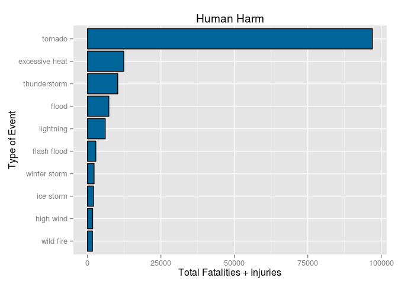

```r
plotData <- stormDataByEventCategory[order(totalHumanHarm, decreasing = TRUE), ]
plotData <- plotData[1:10, ]

# plot the graph
g <- ggplot(plotData, aes(EventCategory, totalHumanHarm))
g + geom_bar(color="black", fill="#006699", stat="identity") +
    labs(x = "Type of Event", y = "Total Fatalities + Injuries", title = "Human Harm") +
    coord_flip() +
    scale_x_discrete(limits = rev(plotData$EventCategory), labels = rev(plotData$EventCategory))
```

#### Economic Damage

The results below show that `tornadoes`, `hail`, `floods`, and `wind from thunderstorms` cause the greatest amount of economic damage, with each appearing at the top of the lists of the type of events that cause the most property and crop damage.

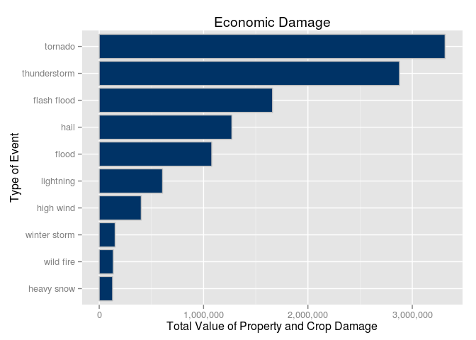

```r
plotData <- stormDataByEventCategory[order(totalEconomicDamage, decreasing = TRUE), ]
plotData <- plotData[1:10, ]

# plot the graph
g <- ggplot(plotData, aes(EventCategory, totalEconomicDamage))
g + geom_bar(color="gray", fill="#003366", stat="identity") +
    labs(x = "Type of Event", y = "Total Value of Property and Crop Damage", title = "Economic Damage") +
    coord_flip() +
    scale_x_discrete(limits = rev(plotData$EventCategory), labels = rev(plotData$EventCategory)) +
    scale_y_continuous(labels = comma)
```

#### Results of Analysis from Municipal Manager’s Perspective

From the perspective of the municipal manager, the analysis below highlights a prioritization list for the next year based on the average number of events likely to occur in a given year and the average impact of each event in that event category. Their product produces metrics for estimated human harm and estimated economic damage over the next 12 months.

These results show that `tornadoes`, `floods`, `thunderstorms`, and `excessive heat` are the event categories that are most likely to cause the greatest human or economic harm in a given year and ought to be prioritized in the municipal manager’s planning efforts.

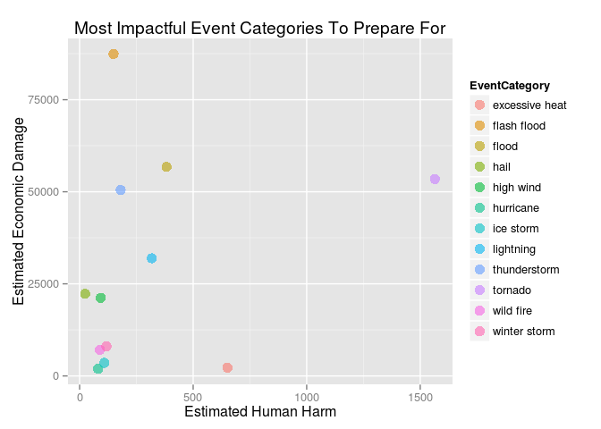

```r
# Focus on the the most impactful event categories
plotData <- stormDataByEventCategory[NTMEstHumanHarm >= 80 | NTMEstEconomicDamage >= 10000, ]

# plot the graph
g <- ggplot(plotData, aes(NTMEstHumanHarm, NTMEstEconomicDamage))
g + geom_point(size = 4, alpha = 0.6, aes(color = EventCategory)) +
    labs(x = "Estimated Human Harm", y = "Estimated Economic Damage", title = "Most Impactful Event Categories To Prepare For")
```